# MicroArray Analysis with Limma

## **4. Working only with rhythmic genes in Dermis/Epidermis – Differential rhythmicity analysis**

We are only going to work with the rhythmic genes we got from `some_rhythm` (genes whose expression was $>$ `amp_cutoff` and whose adjusted $p$ value was $<$ `fdr_cutoff`).

Knowing these rhythmic genes (in our data set), we go to our `yave` and `fit` matrices and select these -> Thus we are going to end with the expression levels (at the different tested time points) + fits of rhythmic genes.

```r
yrhy    <- yave[yave$genes$ProbeName %in% some_rhythm, ] #expression levels of rhythmic genes
fit_rhy <- fit[yave$genes$ProbeName %in% some_rhythm, ] #fits of those rhythmic genes
```

```r
colnames_proper <- gsub(":", "_", colnames(design))
contrast1 <- makeContrasts(tissueD_inphase - tissueE_inphase, tissueD_outphase - tissueE_outphase,
                           levels = colnames_proper) #####?
rownames(contrast1) <- colnames(design)
```

Now we have to extract the linear model fits for the contrasts (from [this](https://www.bioconductor.org/help/course-materials/2005/BioC2005/labs/lab01/estrogen/) tutorial) and after we have the `lm_fit`, we calculate $p$ values with eBayes. We will end up with a matrix like `fit`, but this time our columns in `coefficients` will be our contrasts.

```r
fit_rhy2 <- contrasts.fit(fit = fit_rhy, contrasts = contrast1)
fit_rhy2 <- eBayes(fit_rhy2, trend = TRUE, robust = TRUE)
```

We then organize fit coefficients together with gene annotations and statistics results with `topTable`. $p$ values are adjusted for multiple testing by Benjamini Hochberg. -> Same as before: where does it get the $F, p$ and adjusted $p$ values from?

1. `results2`: contains the fit coefficients, gene anotations and statistics ($p$ value and adjusted $p$ value) of our comparison of inphase/outphase of dermis vs. epidermis. We have tested the hypothesis `inphase_dermis=inphase_epidermis` and `outphase_dermis='outphase_epidermis`. In other words, our $H_0$ was that there are no differences between the rhythmic genes in dermis vs. epidermis. We are getting statistics to these hypotheses.
   - In those genes where adjusted $p$ value < `fdr_cutoff`, we can reject the null hypothesis and say that there are differences between rhythmic (or just expressed?) genes in dermis vs. epidermis. This filtering is what we do on the next step (2)
2. `diff_rhythm`: we filter the `results2` to see which probes have an adjusted $p$ value $<$ `fdr_cutoff` -> These genes will be differentially rhythmic in dermis vs. epidermis.
3. `results_diff_rhythm`: we filter the `diff_rhythm` genes/probes in our `results` data frame (the one containing info about amplitude/phases of all expressed genes) and estimate the amplitude ratio `Aratio` and phase difference `ph_diff` between dermis and epidermis.
   - Note that since `A_E` and `A_D` values are in log2, for the amplitude ratio we just have to substract them. But I don’t get the same value if I do $\frac{2^{A_E}-1} {2^{A_D}-1}$!!!

```r
results2 <- topTable(fit_rhy2, number = Inf, sort.by = "none") %>%
  set_colnames(gsub("\\.","_", colnames(.)))

diff_rhythm <- dplyr::filter(results2, adj_P_Val < fdr_cutoff) %$% ProbeName

results_diff_rhythm <- results %>% dplyr::filter(ProbeName %in% diff_rhythm) %>%
  dplyr::mutate(Aratio = A_E-A_D, ph_diff = (phaseE-phaseD + 12) %% 24 - 12) # %%=mod -> determines remainder
```

### **4.1. Plot of amplitudes of differentially rhythmic genes**

Now we plot the amplitude of dermis vs. amplitude of epidermis, and highlight those genes whose rhythmicity is different in D from E in red. Amplitudes plotted before were in log2!!!!

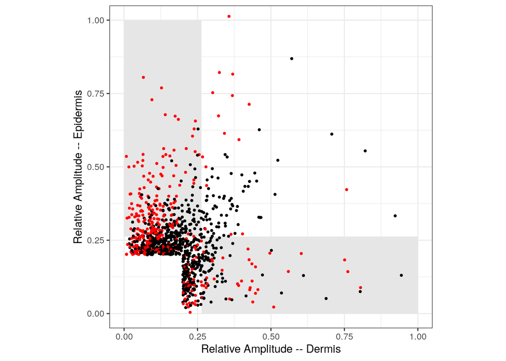

```r
plot_Amplitude_compare_diffrhy <- ggplot(dplyr::filter(results, ProbeName %in% some_rhythm)) +
                                          # rhythm in either-or
  geom_rect(xmin = amp_cutoff, xmax=1, ymin=0, ymax = amp_cutoff, alpha=0.1, fill="grey90") +
  geom_rect(xmin = 0, xmax=amp_cutoff, ymin=amp_cutoff, ymax = 1, alpha=0.1, fill="grey90") +
  geom_point(aes(x=2^A_D-1, y=2^A_E-1,
                 color=factor(ProbeName %in% diff_rhythm, levels=c(TRUE, FALSE))), size=0.75) +
  theme_bw() + theme(aspect.ratio = 1, legend.position = "none") + scale_color_manual(values=c("red", "black")) +
  xlab("Relative Amplitude -- Dermis") + ylab("Relative Amplitude -- Epidermis") +
  coord_cartesian(xlim=c(0,1),ylim=c(0,1))

if (!file.exists("figures/Amplitude_compare_diffrhy.pdf")){
  plot_Amplitude_compare_diffrhy %>% ggsave("figures/Amplitude_compare_diffrhy.pdf", .)
}

plot_Amplitude_compare_diffrhy
```

### **4.2. Histograms of amplitude/phase differences between those DR genes in E vs D**

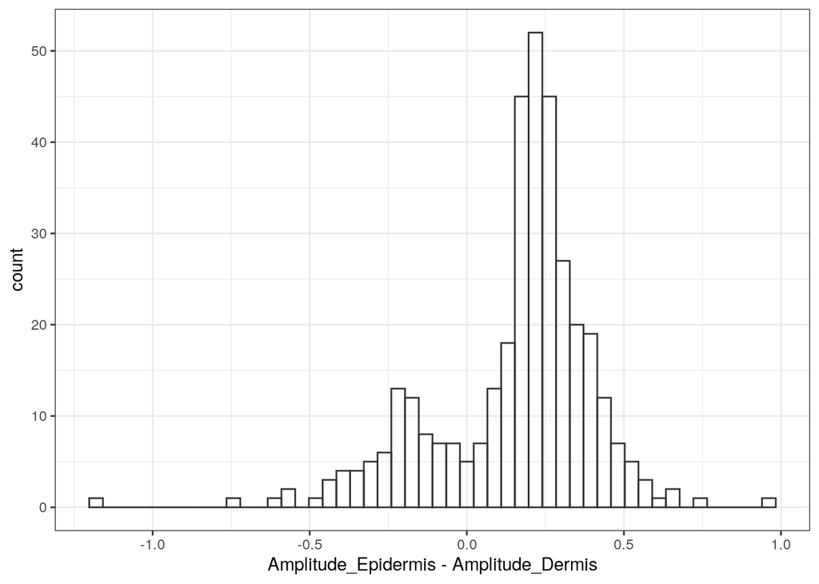

```r
plot_Histogram_amplitudes <- ggplot(results_diff_rhythm) +
  geom_histogram(aes(x=Aratio),bins = 50, fill=NA, color="grey20") +
  theme_bw() +
  xlab("Amplitude_Epidermis - Amplitude_Dermis")
plot_Histogram_amplitudes
```

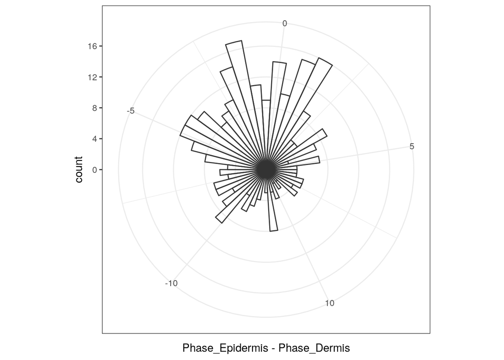

```r
plot_Histogram_phases <- ggplot(results_diff_rhythm) +
  geom_histogram(aes(x=ph_diff),bins = 50, fill=NA, color="grey20") +
  theme_bw() +
  xlab("Phase_Epidermis - Phase_Dermis") + coord_polar(start = pi/50+pi)
plot_Histogram_phases
```

### **4.3. Correlation Aratio vs. phase_difference of DR genes**

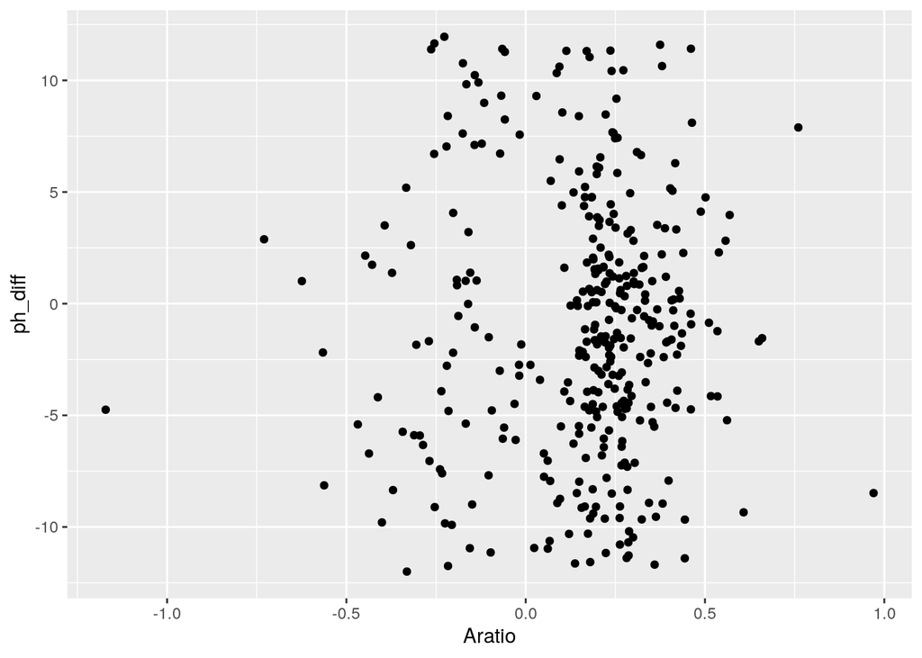

```r
plot_Amplitude_phase_corr <- ggplot(results_diff_rhythm) +
  geom_point(aes(x=Aratio, y=ph_diff))
plot_Amplitude_phase_corr
```

### **4.4. Plot rhythms in D and E from DR genes**

To get the fitted values:

1. We get the coefficients from `inphase` and `outphase` columns from our `fit` (genes expressed either-or) (dimensions = 11578 x 4)
2. We multiply this matrix times the `design` matrix (transposed) (dimensions of transposed matrix = 4*154)
- Remember that, in order to multiply matrices, columns of matrix $M_1$ must be equal to rows of matrix $M_2$
3. As a results of this matrix multiplication, the dimensions of my new matrix $M_3$ are: rows = rows $M_1$, columns = columns $M_2$ -> 11578 x 154. This means that for each gene, I have 154 measurements (11 patients * 7 time points * 2 tissues). In other words, for each gene I get the “fitted” timeseries for all patients in both tissues!! :)

```r
fitted_values <- fit$coefficients[, rhy_indices] %*% t(design[, rhy_indices]) %>%
                 set_rownames(fit$genes$Symbol) %>%
                 set_colnames(colnames(yave$E))
```

Our aim is to plot the rhythm of the DR genes in epidermis vs. dermis.

1. We filter the `results_diff_rhythmic` such that we end with genes whose amp is $>$ the `amp_cutoff` in **both** tissues -> that’s why we force the `min` of the pair of `(A_D, A_E)` values to be $>$ ``amp_cutoff`
2. We organize the data into `mean_data` by:
- Taking `yave$E` (11578 x 154) and adding two columns, corresponding to `ProbeName` and `Symbol`
- `gather` the data: leave ProbeName + Symbol and gather the info of patient+tissue (`junk`) and the expression `value`
- `separate` the `junk` column to `tissuetime` + `subject`
- `separate` `tissuetime` in `tissue` + `time`
- Filter the DR genes
- Calculate, for example, the mean of Dermis_08, Dermis_12, etc. of across all subjects, and then substract the original value - the `mean(value)`

```r
in_both_rhythm <- results_diff_rhythm %>% dplyr::filter(pmin(A_D, A_E) > amp_cutoff)

mean_data <- yave$E %>% transform(ProbeName = yave$genes$ProbeName,
                     Symbol = yave$genes$Symbol) %>% as_tibble() %>%
                     #transform is the same as dplyr::mutate, just that works for matrices
                     #this matrix is 11578 (#genes) x 156 (#samples + col=ProbeName + col=Symbol)
         tidyr::gather(junk, value, -ProbeName, -Symbol) %>%
         tidyr::separate(junk, c("tissuetime","subject"), sep = "_", convert = TRUE) %>%
         tidyr::separate(tissuetime, c("tissue","time"), convert = TRUE, sep = 1) %>%
         dplyr::filter(ProbeName %in% diff_rhythm) %>%
         dplyr::group_by(ProbeName, Symbol, tissue, time) %>%
         dplyr::summarise(value = mean(value)) %>%
            #value == mean value across all patients (mean of D08, D12, D16... across subjects)
         dplyr::mutate(value = value - mean(value))
```

Now we have the mean expression value (across subjects) of each gene, for each tissue and each time point. Let’s plot the subject-mean rhythms.

```r
page_no <- 8 #8 pages with n_pages
             #(https://www.programmingwithr.com/how-to-make-your-facet-wrap-facet-grid-ggplots-span-across-multiple-pages-in-pdf/)

for (i in 1:page_no){
  p <- ggplot(mean_data) +
    geom_rect(xmin=4,xmax=36,ymin=-amp_cutoff,ymax=amp_cutoff, fill="grey80", alpha=0.1) +
    geom_line(aes(x=time, y=value, group=tissue, color=tissue)) +
    facet_wrap_paginate(~Symbol, ncol=8, nrow = 9, page=i) + theme_bw(base_size = 8) +
    theme(aspect.ratio = 1, strip.text = element_text(size=6), legend.position = "top")

  if (!file.exists(sprintf("figures/Diff_rhy_genes_%d.pdf", i))){
    p %>% ggsave(sprintf("figures/Diff_rhy_genes_%d.pdf", i),.,width = 7,height = 10)
  }
}
```